# Computational Linear Algebra Midterm 1: Take-Home Portion

Vichearith Meas

*Due Tuesday, March 1, 2022, 9:00AM sharp. Please submit an html (or pdf) of your completed work on Moodle. If you wish to write things on paper to complement your typed work, you can upload a picture/scan of your work to Moodle.*

The following line sources functions from the class file `365Functions.r`. Feel free to use any of these functions.

```r
source('https://www.macalester.edu/~dshuman1/365/365Functions.r')
```

## Problem 5: Multivariate Rootfinding via Newton’s Method

1. Briefly explain why Algorithm 2 is better than Algorithm 1.

In Algorithm 2, we solve for $s = DF(x_{k-1})^{-1}F(x_{k-1})$ first. In each iteration, solving for $s$ can be efficient. $s = DF(x_{k-1})^{-1}F(x_{k-1}) \quad \Rightarrow \quad DF(x_{k-1})s = - F(x_{k-1})$.

Solving this equation is like solving regular $Ax = b$ assuming $DF(x_{k-1}) = A$ and $b = -F(x_{k-1})$. Solving $Ax= b$ is way more efficient than finding $A^{-1}$ and do dot multiplication.

2. Write a function that implements Algorithm 2 Then test your function example system given in equation (3), with $x_0=(0.5,0.5)$.

```r
vnorm <- function(v,p=2) {
  if ( p =="I") {
    return(max(abs(v)))
  }
  else {
    return(sum(abs(v)^p)^(1/p))
  }
}


mvnewt <- function(F,DF,x0,maxiter=100,tol=1e-8) {
 #  N: dimention of x
  N = length(x0)
 #  history to save prediction
  history = spMatrix(N,maxiter + 1)
  history[,1] = x0          #add first prediction
  #  record iteration
  steps=0

  for (j in 2:(maxiter+1)) {
    steps <- steps+1
    prevX = history[,(j-1)]
    s = solve(DF(prevX), -F(prevX))
    history[,j] = prevX + s
    if (vnorm(s,2) <= vnorm(prevX,2)*tol) break
  }
  return(list(x=history[,(steps+1)],iterations=steps,history = history))
}
```

```r
DF  = function(x){
  u = x[1]
  v = x[2]
  return(matrix(c(-2*u, 1, 2*u , 2*v), nrow = 2, ncol = 2))
}

F = function(x){
  u = x[1]
  v = x[2]
  return(c(-u^2 + v, u^2 + v^2 - 1))
}

x0 = c(0.5,0.5)
mvnewt_estimation = mvnewt(F, DF, x0, tol=1e-30)

mvnewt_estimation$x
```

```
## [1] 0.7861514 0.6180340
```

```r
F(mvnewt_estimation$x)
```

```
## [1] 1.110223e-16 0.000000e+00
```

3. Find the two roots for the system of equations (4).

We have:

$$F(u,v,w) = \begin{pmatrix}
u^2 + v^2 + w^2 -4 \\
sin(2\pi v)- w \\
u - v^2
\end{pmatrix}
\\
DF(u,v,w) = \begin{pmatrix}
2u & 2v & 2w \\
0 & 2\pi cos(2\pi v) & -1 \\
1 & -2v & 0
\end{pmatrix}$$

```r
Fc = function(x){
  u = x[1]
  v = x[2]
  v2 = v*v
  w = x[3]
  return(c(u^2 + v2 + w^2 - 4, sin(2*pi*v) - w , u - v2))
}
DFc = function(x){
  u = x[1]
  v = x[2]
  w = x[3]
  return(matrix(c(
    2*u, 2*v ,  2*w,
    0 ,  2*pi*cos(2*pi*v), -1,
    1, -2*v, 0
  ), nrow= 3, ncol= 3 , byrow=TRUE))
}
```

```r
initial_guess = list(
  c(1,1,1),
  c(-1,1,1),
  c(0,1,-1),
  c(2,-1,1),
  c(1,2,1),
  c(-1,2,1),
  c(-1,1,-2),
  c(2,0,1),
  c(20,10,10),
  c(-20,-10,-10),
  c(20,10,-10),
  c(-20,10,10)
)

for( i in initial_guess ){
xc = mvnewt(Fc, DFc, i)
print(xc$x)
print(Fc(xc$x))
}
```

```
## [1] 1.367120 1.169239 0.873993
## [1] 0.000000e+00 3.330669e-16 0.000000e+00
## [1]  1.367120 -1.169239 -0.873993
## [1]  0.000000e+00 -1.110223e-16 -2.220446e-16
## [1] 1.367120 1.169239 0.873993
## [1] 0.000000e+00 3.330669e-16 0.000000e+00
## [1]  1.367120 -1.169239 -0.873993
## [1]  0.000000e+00 -2.220446e-16 -2.220446e-16
## [1] 1.367120 1.169239 0.873993
## [1]  0.000000e+00  2.220446e-16 -2.220446e-16
## [1]  1.367120 -1.169239 -0.873993
## [1]  0.000000e+00 -3.330669e-16 -2.220446e-16
## [1]  1.367120 -1.169239 -0.873993
## [1]  0.000000e+00 -1.110223e-16 -2.220446e-16
## [1] 1.367120 1.169239 0.873993
## [1] 0.000000e+00 3.330669e-16 0.000000e+00
## [1] 1.367120 1.169239 0.873993
## [1]  0.000000e+00  2.220446e-16 -2.220446e-16
## [1]  1.367120 -1.169239 -0.873993
## [1]  0.000000e+00 -2.220446e-16 -2.220446e-16
## [1]  1.367120 -1.169239 -0.873993
## [1]  0.000000e+00 -3.330669e-16 -2.220446e-16
## [1] 1.367120 1.169239 0.873993
## [1]  0.000000e+00  2.220446e-16 -2.220446e-16
```

The estimation for the roots given by the algorithm are $( 1.367119749, -1.169238961, -0.873993046)$ and $( 1.367119749, 1.169238961, 0.873993046)$

## Problem 6: Multivariate Rootfinding without a Jacobian Matrix

1. Write a function that implements Algorithm 2

```r
mvroot <- function(F,J0,x0,maxiter = 100,tol = 1e-8){
 #  N: dimention of x
  N = length(x0)
 #  history to save prediction
  history = spMatrix(N,maxiter + 1)
  history[,1] = x0          #add first prediction
  #  record iteration
  steps=0
  # delta

  for (j in 2:(maxiter+1)) {
    steps <- steps+1
    prevX = history[,(j-1)]
    s = solve(J0, -F(prevX))
    x = prevX + s
    history[,j] = x
    t_s = t(s)
    J0 = J0 + ((F(x) - F(prevX) - J0%*%s)%*%t_s)/(as.vector(t_s%*%s))
    if (vnorm(s,2) <= vnorm(prevX,2)*tol) break
  }
  return(list(x=history[,(steps+1)],iterations=steps,history = history))
}
```

Then test your function example system given in equation (3), with $J_0$ equal to the 2x2 identity matrix and $x_0=(0.5,0.5)$

```r
J0 = diag(1,nrow = 2)
x0_6 = c(0.5,0.5)
mvroot_estimation = mvroot(F, J0, x0_6, maxiter = 100)
mvroot_estimation
```

```
## $x
## [1] -0.7861514  0.6180340
##
## $iterations
## [1] 15
##
## $history
## 2 x 101 sparse Matrix of class "dgTMatrix"
##
## [1,] 0.5 0.25 -2.4285714 0.1046234 -0.1525752 -10.9527042 -0.2061000 -0.2576701
## [2,] 0.5 1.00  0.8214286 0.6144326  0.6187745   0.6431335  0.6181497  0.6180649
##
## [1,] -1.4487402 -0.5809562 -0.7191750 -0.7967239 -0.7856847 -0.7861483
## [2,]  0.6177718  0.6180274  0.6180275  0.6180331  0.6180338  0.6180340
##
## [1,] -0.7861514 -0.7861514 . . . . . . . . . . . . . . . . . . . . . . . . . .
## [2,]  0.6180340  0.6180340 . . . . . . . . . . . . . . . . . . . . . . . . . .
##
## [1,] . . . . . . . . . . . . . . . . . . . . . . . . . . . . . . . . . . . . .
## [2,] . . . . . . . . . . . . . . . . . . . . . . . . . . . . . . . . . . . . .
##
## [1,] . . . . . . . . . . . . . . . . . . . . . .
## [2,] . . . . . . . . . . . . . . . . . . . . . .
```

2. Compare the convergence rates for the multivariate Newton method and the Jacobian-free method. Do they converge linearly? superlinearly? quadratically? Support your answer with numerical evidence.

Solving for exact root:
$$\begin{cases}
-u^2 + v = 0 \\
u^2 + v^2 = 1
\end{cases}\Rightarrow
v^2 + v -1 = 0
\Rightarrow
\begin{cases}
v = \frac{-1+\sqrt{5}}{2}, u = \sqrt{\frac{-1+\sqrt{5}}{2}} \\
v = \frac{-1+\sqrt{5}}{2}, u = - \sqrt{\frac{-1+\sqrt{5}}{2}} \\
\end{cases}$$

```r
(root_1 = c(-sqrt((- 1 + sqrt(5) )/2 ), (-1 + sqrt(5))/2))
```

```
## [1] -0.7861514  0.6180340
```

```r
(root_2 = c(sqrt((- 1 + sqrt(5) )/2 ), (-1 + sqrt(5))/2))
```

```
## [1] 0.7861514 0.6180340
```

```r
# mvnewt_estimation$history
mvnewt_errors = rep(0, ncol(mvnewt_estimation$history))
for (i in 1:ncol(mvnewt_estimation$history)){
  mvnewt_errors[i] = vnorm(mvnewt_estimation$history[,i] - root_2,p = 2)
}

mvroot_errors = rep(0, ncol(mvroot_estimation$history))
for (i in 1:ncol(mvroot_estimation$history)){
  mvroot_errors[i] = vnorm(mvroot_estimation$history[,i] - root_1,p = 2)
}
```

```r
mvn_q = data.frame(x = 1:34,
                   linear = mvnewt_errors[2:35]/mvnewt_errors[1:34],
                   superlinear = mvnewt_errors[2:35]/(mvnewt_errors[1:34]^1.5),
                  quadratic = mvnewt_errors[2:35]/(mvnewt_errors[1:34]^2))

mvr_q =  data.frame(x= 1:15,
                    linear = mvroot_errors[2:16]/mvroot_errors[1:15],
                   superlinear = mvroot_errors[2:16]/(mvroot_errors[1:15]^1.5),
                    quadratic = mvroot_errors[2:16]/(mvroot_errors[1:15]^2))
mvr_q
```

```
##     x       linear  superlinear    quadratic
## 1   1  0.855025310 7.523541e-01 6.620117e-01
## 2   2  1.498638349 1.426102e+00 1.357077e+00
## 3   3  0.538247882 4.183962e-01 3.252320e-01
## 4   4  0.711258905 7.536019e-01 7.984657e-01
## 5   5 16.046335972 2.015934e+01 2.532659e+01
## 6   6  0.057054704 1.789386e-02 5.611984e-03
## 7   7  0.911093902 1.196272e+00 1.570712e+00
## 8   8  1.253760317 1.724645e+00 2.372383e+00
## 9   9  0.309686950 3.804528e-01 4.673893e-01
## 10 10  0.326403492 7.205618e-01 1.590698e+00
## 11 11  0.157854526 6.099526e-01 2.356868e+00
## 12 12  0.044142824 4.293097e-01 4.175238e+00
## 13 13  0.006550216 3.032048e-01 1.403514e+01
## 14 14  0.003290496 1.881976e+00 1.076383e+03
## 15 15  0.127245287 1.268714e+03 1.264986e+07
```

```r
mvn_q
```

```
##     x    linear  superlinear    quadratic
## 1   1 0.2879158 5.174967e-01 9.301427e-01
## 2   2 0.4127787 1.382696e+00 4.631652e+00
## 3   3 0.3280122 1.710176e+00 8.916437e+00
## 4   4 0.3693415 3.362279e+00 3.060831e+01
## 5   5 0.3405494 5.101192e+00 7.641229e+01
## 6   6 0.3624499 9.303567e+00 2.388091e+02
## 7   7 0.3478525 1.483107e+01 6.323391e+02
## 8   8 0.3595539 2.599226e+01 1.878988e+03
## 9   9 0.3514929 4.237547e+01 5.108724e+03
## 10 10 0.3577702 7.275180e+01 1.479392e+04
## 11 11 0.3533183 1.201168e+02 4.083582e+04
## 12 12 0.3567040 2.040152e+02 1.166856e+05
## 13 13 0.3542601 3.392523e+02 3.248802e+05
## 14 14 0.3560934 5.729323e+02 9.218128e+05
```

[output cut: 20 more lines]

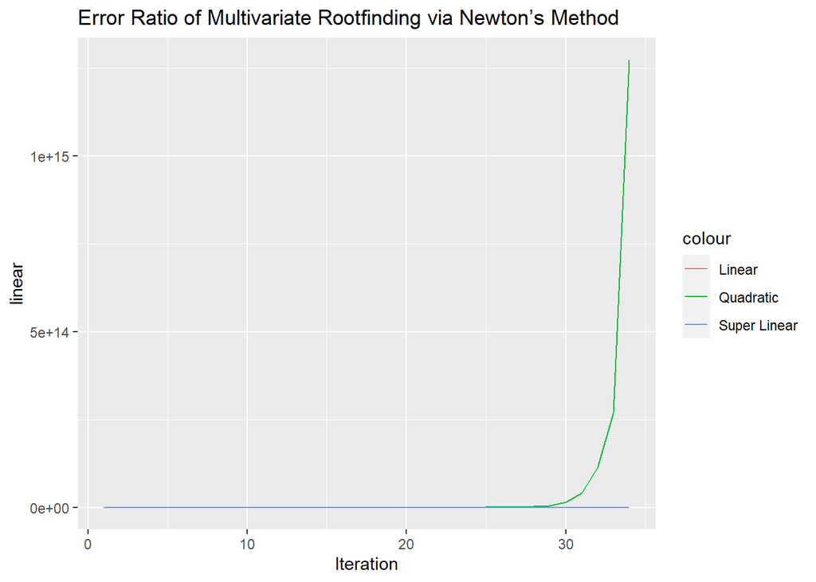

```r
ggplot(mvn_q, aes(x = x)) +
  geom_line(aes(y = linear, colour = "Linear")) +
  geom_line(aes(y = quadratic, colour = "Quadratic"))+
  geom_line(aes(y = superlinear, colour = "Super Linear"))  +
  labs(title= 'Error Ratio of Multivariate Rootfinding via Newton’s Method',
       x = 'Iteration')  +
  theme(axis.title.x = element_text("Iteration"),
        axis.title.y = element_text("Error Ratio"))
```

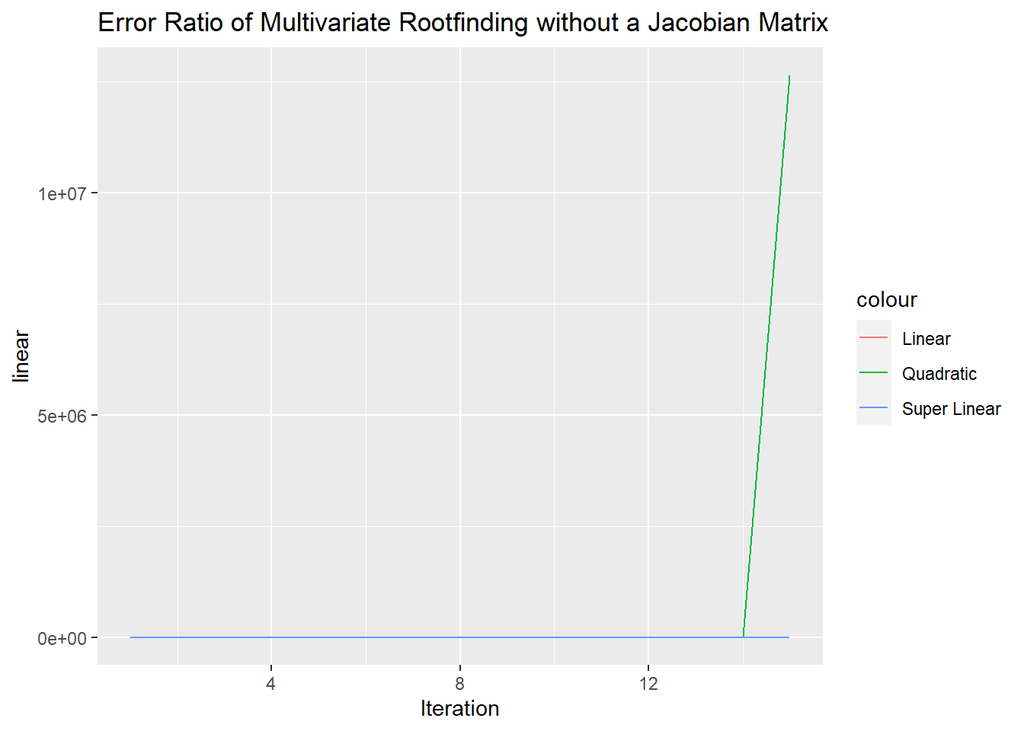

```r
ggplot(mvr_q, aes(x = x)) +
  geom_line(aes(y = linear, colour = "Linear")) +
  geom_line(aes(y = quadratic, colour = "Quadratic"))+
  geom_line(aes(y = superlinear, colour = "Super Linear"))  +
  labs(title= 'Error Ratio of Multivariate Rootfinding without a Jacobian Matrix',
       x = 'Iteration') +
  theme(axis.title.x = element_text("Iteration"),
        axis.title.y = element_text("Error Ratio"))
```

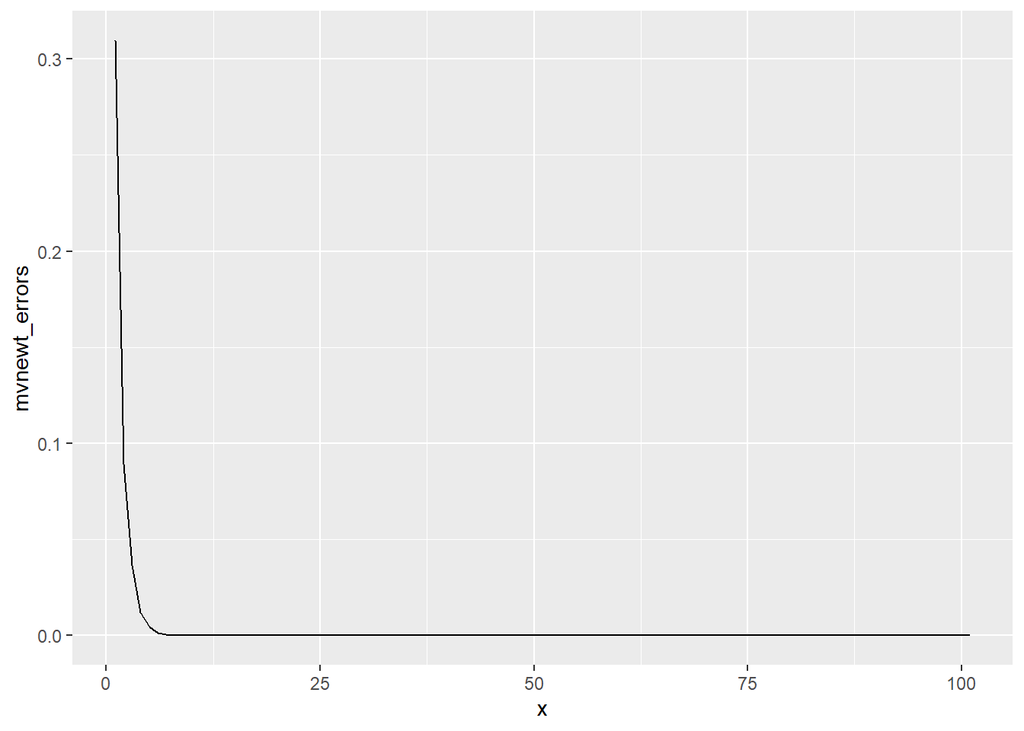

```r
mvnewt_errors =  data.frame(mvnewt_errors, x = 1:101)

mvnewt_errors %>%
  ggplot() +
  geom_line(aes(x = x, y = mvnewt_errors ))
```

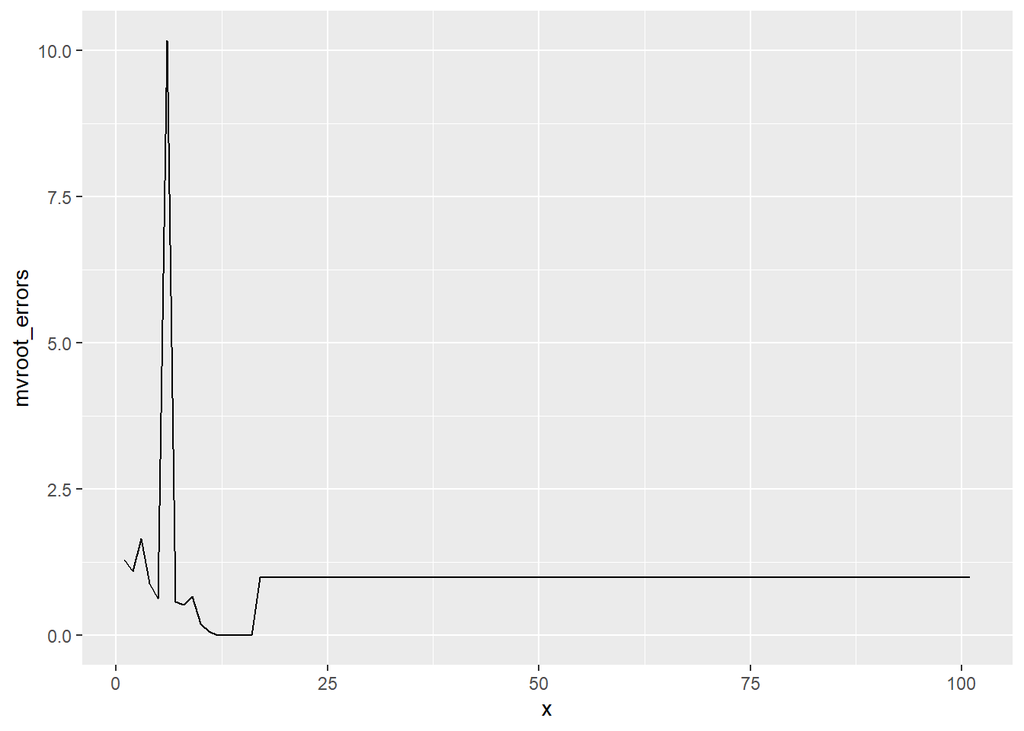

```r
mvroot_errors = data.frame(mvroot_errors, x = 1:101)
mvroot_errors %>%
  ggplot() +
  geom_line(aes(x = x, y = mvroot_errors))
```